# Student Depression

## Main Objective:

The purpose of this project is to build a predictive machine learning model that will predict who will get depressed.

We will be building our regression models using the dataset “Student Depression Dataset: Analyzing Mental Health Trends and Predictors Among Students”, created by Adil Shamim. The dataset, which is sourced from Kaggle.com, compiles a wide range of information about students in various cities across India.

### Key Highlights of Dataset

- Dataset Source: Student Depression Dataset (https://www.kaggle.com/datasets/adilshamim8/student-depression-dataset)
- Dataset: There were 27901 records present. It was mostly complete, with only 3 missing values in the “Financial Stress” column.
- Depression (Target Variable): This binary column shows if a student is experiencing depression (“0” = No and “1” = Yes).
- Other Binary Variable: The “Have you ever had suicidal thoughts?” & “Family History of Mental Illness” consist of “Yes” and “No” string values.

## Importing Libraries

```python
import numpy as np
import pandas as pd
import matplotlib.pyplot as plt
import seaborn as sns
import statsmodels.formula.api as smf

from sklearn.preprocessing import MinMaxScaler
from sklearn.preprocessing import StandardScaler
from sklearn.model_selection import train_test_split
from sklearn.metrics import accuracy_score
from sklearn.metrics import confusion_matrix, ConfusionMatrixDisplay
from sklearn.metrics import roc_auc_score
from sklearn.metrics import classification_report

from sklearn.neighbors import KNeighborsClassifier
from sklearn.linear_model import LogisticRegression
from sklearn.discriminant_analysis import LinearDiscriminantAnalysis
from sklearn.ensemble import RandomForestClassifier
from sklearn.model_selection import cross_val_score, KFold

%matplotlib inline
```

# Part 1

### Read dataset from "student_depression_dataset"

```python
df = pd.read_csv('student_depression_dataset.csv', sep=',', header=0)
```

## Data Exploration

```python
df.head(5)
```

|  | id | Gender | Age | City | Profession | Academic Pressure | Work Pressure | CGPA | Study Satisfaction | Job Satisfaction | Sleep Duration | Dietary Habits | Degree | Have you ever had suicidal thoughts ? | Work/Study Hours | Financial Stress | Family History of Mental Illness | Depression |
| --- | --- | --- | --- | --- | --- | --- | --- | --- | --- | --- | --- | --- | --- | --- | --- | --- | --- | --- |
| 0 | 2 | Male | 33.0 | Visakhapatnam | Student | 5.0 | 0.0 | 8.97 | 2.0 | 0.0 | '5-6 hours' | Healthy | B.Pharm | Yes | 3.0 | 1.0 | No | 1 |
| 1 | 8 | Female | 24.0 | Bangalore | Student | 2.0 | 0.0 | 5.90 | 5.0 | 0.0 | '5-6 hours' | Moderate | BSc | No | 3.0 | 2.0 | Yes | 0 |
| 2 | 26 | Male | 31.0 | Srinagar | Student | 3.0 | 0.0 | 7.03 | 5.0 | 0.0 | 'Less than 5 hours' | Healthy | BA | No | 9.0 | 1.0 | Yes | 0 |
| 3 | 30 | Female | 28.0 | Varanasi | Student | 3.0 | 0.0 | 5.59 | 2.0 | 0.0 | '7-8 hours' | Moderate | BCA | Yes | 4.0 | 5.0 | Yes | 1 |
| 4 | 32 | Female | 25.0 | Jaipur | Student | 4.0 | 0.0 | 8.13 | 3.0 | 0.0 | '5-6 hours' | Moderate | M.Tech | Yes | 1.0 | 1.0 | No | 0 |

```python
df.info()
```

```
<class 'pandas.core.frame.DataFrame'>
RangeIndex: 27901 entries, 0 to 27900
Data columns (total 18 columns):
 #   Column                                 Non-Null Count  Dtype
---  ------                                 --------------  -----
 0   id                                     27901 non-null  int64
 1   Gender                                 27901 non-null  object
 2   Age                                    27901 non-null  float64
 3   City                                   27901 non-null  object
 4   Profession                             27901 non-null  object
 5   Academic Pressure                      27901 non-null  float64
 6   Work Pressure                          27901 non-null  float64
 7   CGPA                                   27901 non-null  float64
 8   Study Satisfaction                     27901 non-null  float64
 9   Job Satisfaction                       27901 non-null  float64
 10  Sleep Duration                         27901 non-null  object
 11  Dietary Habits                         27901 non-null  object
 12  Degree                                 27901 non-null  object
 13  Have you ever had suicidal thoughts ?  27901 non-null  object
 14  Work/Study Hours                       27901 non-null  float64
 15  Financial Stress                       27901 non-null  object
 16  Family History of Mental Illness       27901 non-null  object
 17  Depression                             27901 non-null  int64
dtypes: float64(7), int64(2), object(9)
memory usage: 3.8+ MB
```

```python
df.dtypes
```

```
id                                         int64
Gender                                    object
Age                                      float64
City                                      object
Profession                                object
Academic Pressure                        float64
Work Pressure                            float64
CGPA                                     float64
Study Satisfaction                       float64
Job Satisfaction                         float64
Sleep Duration                            object
Dietary Habits                            object
Degree                                    object
Have you ever had suicidal thoughts ?     object
Work/Study Hours                         float64
Financial Stress                          object
Family History of Mental Illness          object
Depression                                 int64
dtype: object
```

### Summary of Statistics for Numerical Features

```python
df.describe()
```

|  | id | Age | Academic Pressure | Work Pressure | CGPA | Study Satisfaction | Job Satisfaction | Work/Study Hours | Depression |
| --- | --- | --- | --- | --- | --- | --- | --- | --- | --- |
| count | 27901.000000 | 27901.000000 | 27901.000000 | 27901.000000 | 27901.000000 | 27901.000000 | 27901.000000 | 27901.000000 | 27901.000000 |
| mean | 70442.149421 | 25.822300 | 3.141214 | 0.000430 | 7.656104 | 2.943837 | 0.000681 | 7.156984 | 0.585499 |
| std | 40641.175216 | 4.905687 | 1.381465 | 0.043992 | 1.470707 | 1.361148 | 0.044394 | 3.707642 | 0.492645 |
| min | 2.000000 | 18.000000 | 0.000000 | 0.000000 | 0.000000 | 0.000000 | 0.000000 | 0.000000 | 0.000000 |
| 25% | 35039.000000 | 21.000000 | 2.000000 | 0.000000 | 6.290000 | 2.000000 | 0.000000 | 4.000000 | 0.000000 |
| 50% | 70684.000000 | 25.000000 | 3.000000 | 0.000000 | 7.770000 | 3.000000 | 0.000000 | 8.000000 | 1.000000 |
| 75% | 105818.000000 | 30.000000 | 4.000000 | 0.000000 | 8.920000 | 4.000000 | 0.000000 | 10.000000 | 1.000000 |
| max | 140699.000000 | 59.000000 | 5.000000 | 5.000000 | 10.000000 | 5.000000 | 4.000000 | 12.000000 | 1.000000 |

### Initial Data Cleaning

Upon reviewing the data types, the 'Financial Stress' variable should be a 'float' data type instead of an 'object'.

```python
df['Financial Stress'] = pd.to_numeric(df['Financial Stress'], errors='coerce' )
df.dtypes
```

```
id                                         int64
Gender                                    object
Age                                      float64
City                                      object
Profession                                object
Academic Pressure                        float64
Work Pressure                            float64
CGPA                                     float64
Study Satisfaction                       float64
Job Satisfaction                         float64
Sleep Duration                            object
Dietary Habits                            object
Degree                                    object
Have you ever had suicidal thoughts ?     object
Work/Study Hours                         float64
Financial Stress                         float64
Family History of Mental Illness          object
Depression                                 int64
dtype: object
```

#### Finding and Addressing Missing Data

```python
print(df.isna().sum())
```

```
id                                       0
Gender                                   0
Age                                      0
City                                     0
Profession                               0
Academic Pressure                        0
Work Pressure                            0
CGPA                                     0
Study Satisfaction                       0
Job Satisfaction                         0
Sleep Duration                           0
Dietary Habits                           0
Degree                                   0
Have you ever had suicidal thoughts ?    0
Work/Study Hours                         0
Financial Stress                         3
Family History of Mental Illness         0
Depression                               0
dtype: int64
```

It is found only the "Financial Stress" variable is missing data. Given only 3 values are missing, it is best to fill in the missing data with median values. This is allow for those values to avoid being impacted by potential outliers.

```python
df['Financial Stress'] = df['Financial Stress'].fillna(df['Financial Stress'].median())
print(df.isna().sum())
```

```
id                                       0
Gender                                   0
Age                                      0
City                                     0
Profession                               0
Academic Pressure                        0
Work Pressure                            0
CGPA                                     0
Study Satisfaction                       0
Job Satisfaction                         0
Sleep Duration                           0
Dietary Habits                           0
Degree                                   0
Have you ever had suicidal thoughts ?    0
Work/Study Hours                         0
Financial Stress                         0
Family History of Mental Illness         0
Depression                               0
dtype: int64
```

Confirmed the dataset no longer has missing values.

### Visualizing Categorical Data

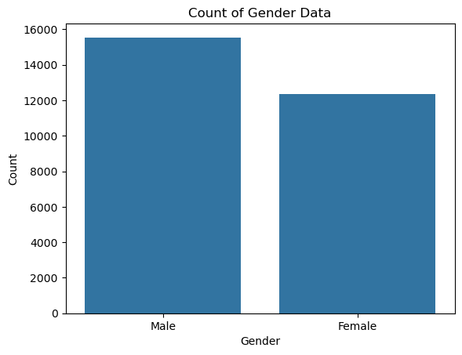

```python
sns.countplot(data=df, x="Gender")
plt.title("Count of Gender Data")
plt.xlabel("Gender")
plt.ylabel("Count")

plt.show()
```

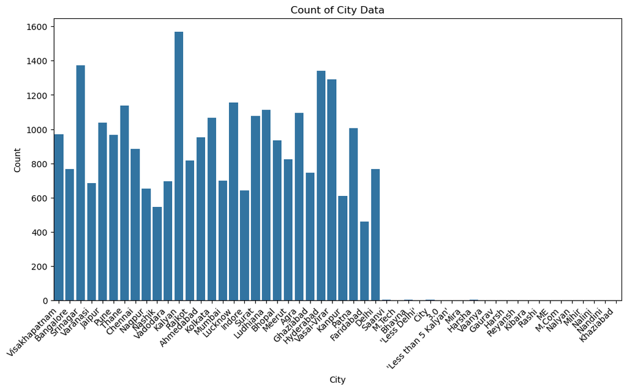

```python
plt.figure(figsize=(12, 6))

sns.countplot(data=df, x="City")
plt.title("Count of City Data")
plt.xlabel("City")
plt.ylabel("Count")
plt.xticks(rotation=45, ha='right')


plt.show()
```

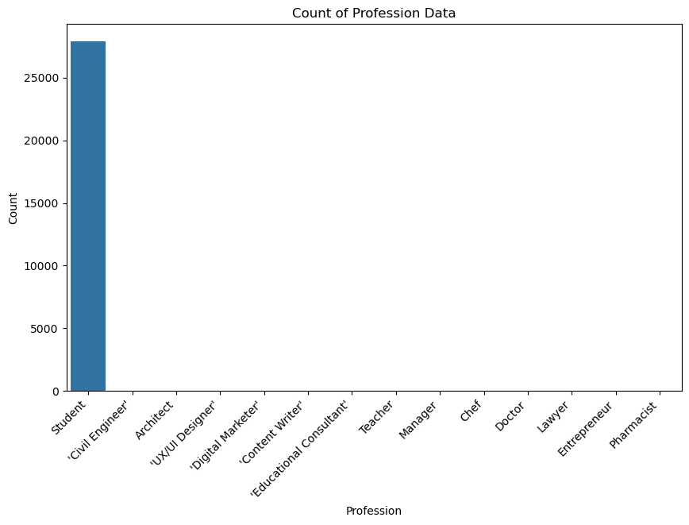

```python
plt.figure(figsize=(10, 6))

sns.countplot(data=df, x="Profession")
plt.title("Count of Profession Data")
plt.xlabel("Profession")
plt.ylabel("Count")
plt.xticks(rotation=45, ha='right')

plt.show()
```

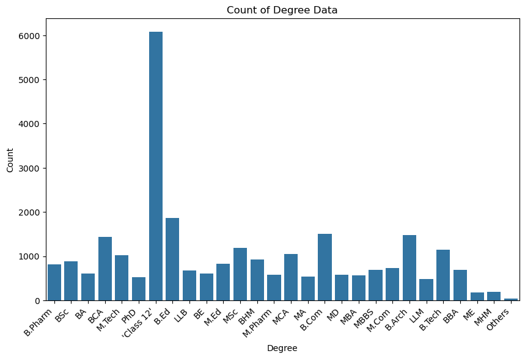

```python
plt.figure(figsize=(10, 6))

sns.countplot(data=df, x="Degree")
plt.title("Count of Degree Data")
plt.xlabel("Degree")
plt.ylabel("Count")
plt.xticks(rotation=45, ha='right')

plt.show()
```

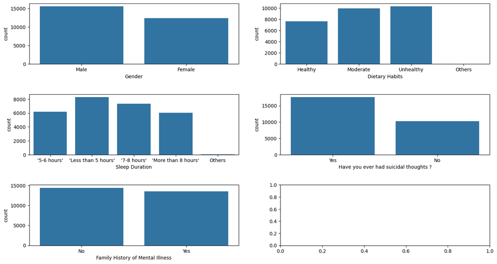

```python
fig, axs = plt.subplots(3, 2, figsize=(17, 9))
sns.countplot(data=df, x="Gender", ax=axs[0, 0])
sns.countplot(data=df, x="Dietary Habits", ax=axs[0, 1])
sns.countplot(data=df, x="Sleep Duration", ax=axs[1, 0])
sns.countplot(data=df, x="Have you ever had suicidal thoughts ?", ax=axs[1, 1])
sns.countplot(data=df, x="Family History of Mental Illness", ax=axs[2, 0])

plt.subplots_adjust(hspace=0.5)
plt.show()
```

#### For the "Degree" Feature, it appears there is a much higher count for the "Class 12" category compared to the other degree types. This indicates there is an imbalance in the classes.

### Validating Numerical Data

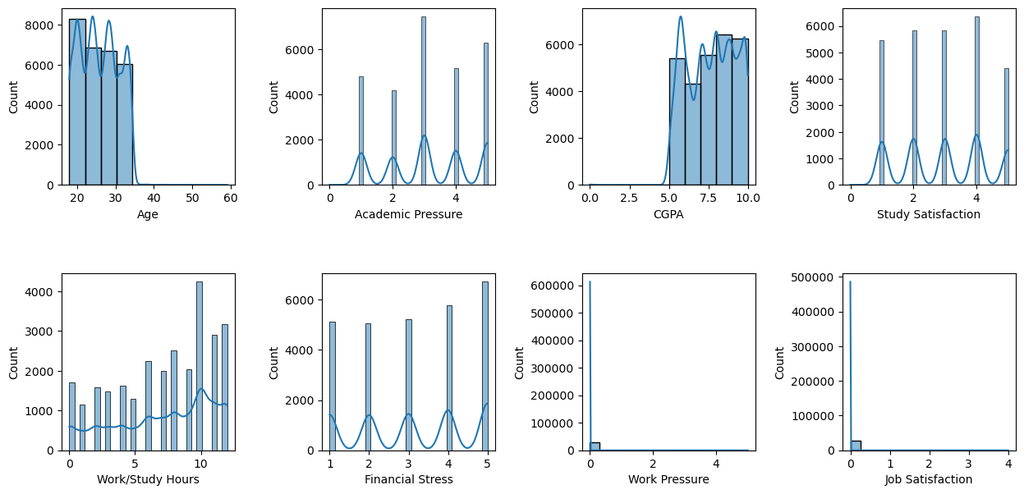

```python
fig, axs = plt.subplots(2, 4, figsize=(15, 7))

sns.histplot(data=df, x="Age", kde=True, bins=10, edgecolor='black', ax=axs[0,0])
sns.histplot(data=df, x="Academic Pressure", kde=True, edgecolor='black', ax=axs[0, 1])
sns.histplot(data=df, x="CGPA", kde=True, bins=10, edgecolor='black', ax=axs[0, 2])
sns.histplot(data=df, x="Study Satisfaction", kde=True, edgecolor='black', ax=axs[0, 3])
sns.histplot(data=df, x="Work/Study Hours", kde=True, edgecolor='black', ax=axs[1, 0])
sns.histplot(data=df, x="Financial Stress", kde=True, edgecolor='black', ax=axs[1, 1])
sns.histplot(data=df, x="Work Pressure", kde=True, edgecolor='black', ax=axs[1, 2])
sns.histplot(data=df, x="Job Satisfaction", kde=True, edgecolor='black', ax=axs[1, 3])

plt.subplots_adjust(hspace=0.5, wspace=0.5)
plt.show()
```

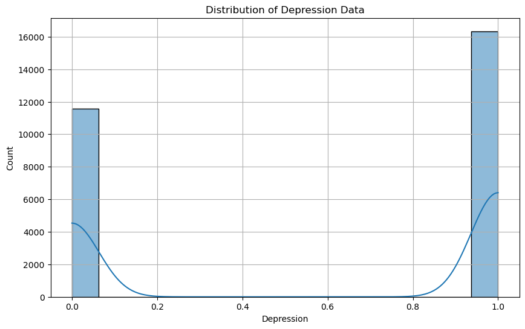

```python
plt.figure(figsize=(10, 6))  # Adjust figure size as needed
sns.histplot(data=df, x="Depression", kde=True, edgecolor='black')
plt.title('Distribution of Depression Data')
plt.xlabel('Depression')
plt.ylabel('Count')
plt.grid(True)
plt.show()
```

#### Discussion:

#### Based on the histogram plots, it appears the data from the numerical features are not normally distributed.

## Initial Correlational Analysis

```python
df.corr(numeric_only='true')
```

|  | id | Age | Academic Pressure | Work Pressure | CGPA | Study Satisfaction | Job Satisfaction | Work/Study Hours | Financial Stress | Depression |
| --- | --- | --- | --- | --- | --- | --- | --- | --- | --- | --- |
| id | 1.000000 | 0.003783 | 0.005172 | 0.001261 | -0.012324 | 0.007794 | 0.001931 | -0.004466 | 0.000785 | 0.000923 |
| Age | 0.003783 | 1.000000 | -0.075803 | 0.002015 | 0.005056 | 0.009235 | -0.000432 | -0.032928 | -0.095023 | -0.226422 |
| Academic Pressure | 0.005172 | -0.075803 | 1.000000 | -0.022231 | -0.022239 | -0.110988 | -0.024945 | 0.095970 | 0.151706 | 0.474835 |
| Work Pressure | 0.001261 | 0.002015 | -0.022231 | 1.000000 | -0.050896 | -0.021145 | 0.770652 | -0.005468 | 0.001883 | -0.003351 |
| CGPA | -0.012324 | 0.005056 | -0.022239 | -0.050896 | 1.000000 | -0.044062 | -0.053631 | 0.002604 | 0.005888 | 0.022210 |
| Study Satisfaction | 0.007794 | 0.009235 | -0.110988 | -0.021145 | -0.044062 | 1.000000 | -0.021907 | -0.036441 | -0.065092 | -0.167971 |
| Job Satisfaction | 0.001931 | -0.000432 | -0.024945 | 0.770652 | -0.053631 | -0.021907 | 1.000000 | -0.005222 | 0.005248 | -0.003482 |
| Work/Study Hours | -0.004466 | -0.032928 | 0.095970 | -0.005468 | 0.002604 | -0.036441 | -0.005222 | 1.000000 | 0.075267 | 0.208563 |
| Financial Stress | 0.000785 | -0.095023 | 0.151706 | 0.001883 | 0.005888 | -0.065092 | 0.005248 | 0.075267 | 1.000000 | 0.363574 |
| Depression | 0.000923 | -0.226422 | 0.474835 | -0.003351 | 0.022210 | -0.167971 | -0.003482 | 0.208563 | 0.363574 | 1.000000 |

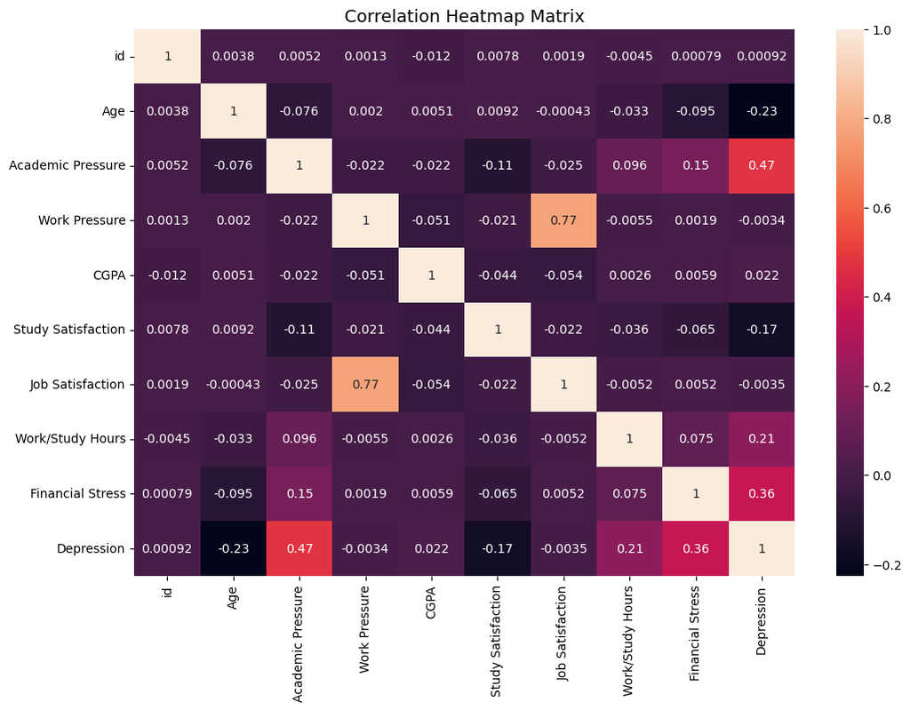

```python
plt.figure(figsize=(12, 8))
sns.heatmap(df.corr(numeric_only='true'), annot=True)
plt.title('Correlation Heatmap Matrix', fontsize=14)
plt.show()
```

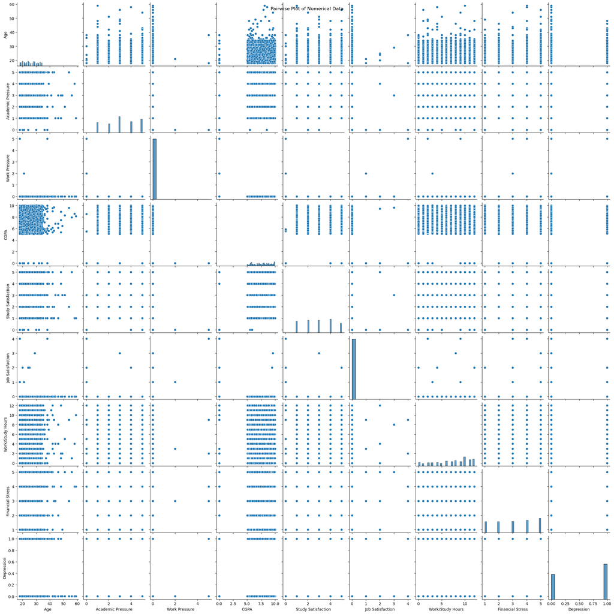

```python
columns = ["Age", "Academic Pressure", "Work Pressure", "CGPA", "Study Satisfaction", "Job Satisfaction", "Work/Study Hours", "Financial Stress", "Depression"]

sns.pairplot(df[columns])
plt.suptitle("Pairwise Plot of Numerical Data")
plt.show()
```

### Discussion:

#### Based on correlation heatmap, the "Depression" target variable has the strongest correlation with the following features.

#### Academic Pressure - Correlation Coefficient = 0.47

#### Financial Stress - Correlation Coefficient = 0.36

#### Work/Study Hours - Correlation Coefficient = 0.21

#### These correlation indicate a positive correlation with the Depression target variable. All of features have a weak correlation with the target variable.

### Categorical Relationships with Depression Target Variable

#### Depression by City

```python
df_filterbyCity = df[["City", "Depression"]]
City_depression_count = df_filterbyCity[df_filterbyCity["Depression"] == 1].groupby("City")["Depression"].count()
#print(City_depression_count)

city_depression_df = pd.DataFrame({
    'City Name': City_depression_count.index,
    'Student Count': City_depression_count.values
})
```

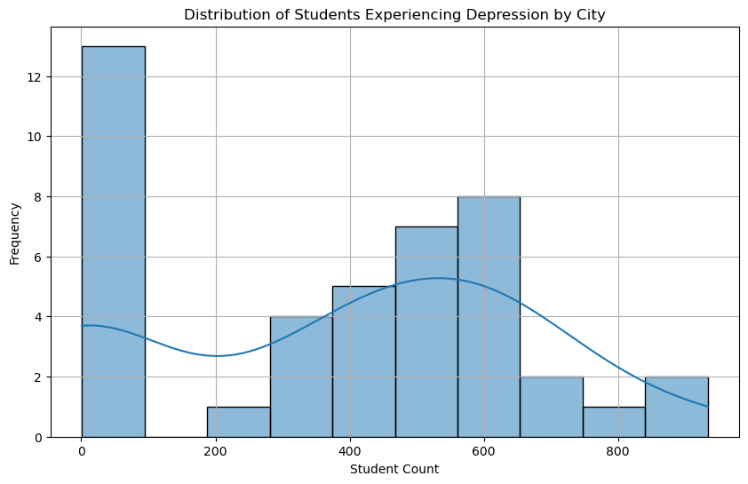

```python
plt.figure(figsize=(10, 6))  # Adjust figure size as needed
sns.histplot(city_depression_df['Student Count'], bins=10, kde=True, edgecolor='black')
plt.title('Distribution of Students Experiencing Depression by City')
plt.xlabel('Student Count')
plt.ylabel('Frequency')
plt.grid(True)
plt.show()
```

#### Depression by Degree

```python
df_filterbyDegree = df[["Degree", "Depression"]]
Degree_depression_count = df_filterbyDegree[df_filterbyDegree["Depression"] == 1].groupby("Degree")["Depression"].count()
#print(City_depression_count)

Degree_depression_df = pd.DataFrame({
    'Degree': Degree_depression_count.index,
    'Student Count': Degree_depression_count.values
})
```

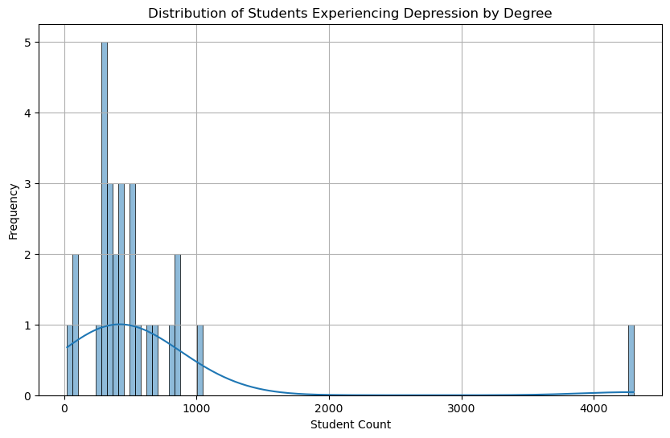

```python
plt.figure(figsize=(10, 6))  # Adjust figure size as needed
sns.histplot(Degree_depression_df['Student Count'], bins=100, kde=True, edgecolor='black')
plt.title('Distribution of Students Experiencing Depression by Degree')
plt.xlabel('Student Count')
plt.ylabel('Frequency')
plt.grid(True)
plt.show()
```

### Depression by Age

```python
df_filterbyAge = df[["Age", "Depression"]]
Age_depression_count = df_filterbyAge[df_filterbyAge["Depression"] == 1].groupby("Age")["Depression"].count()
#print(City_depression_count)

Age_depression_df = pd.DataFrame({
    'Age': Age_depression_count.index,
    'Student Count': Age_depression_count.values
})
```

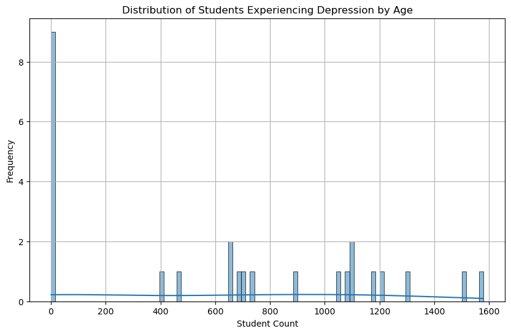

```python
plt.figure(figsize=(10, 6))  # Adjust figure size as needed
sns.histplot(Age_depression_df['Student Count'], bins=100, kde=True, edgecolor='black')
plt.title('Distribution of Students Experiencing Depression by Age')
plt.xlabel('Student Count')
plt.ylabel('Frequency')
plt.grid(True)
plt.show()
```

### Depression by Gender

```python
df_filterbyGender = df[["Gender", "Depression"]]
Gender_depression_count = df_filterbyGender[df_filterbyGender["Depression"] == 1].groupby("Gender")["Depression"].count()
#print(City_depression_count)

Gender_depression_df = pd.DataFrame({
    'Gender': Gender_depression_count.index,
    'Student Count': Gender_depression_count.values
})
```

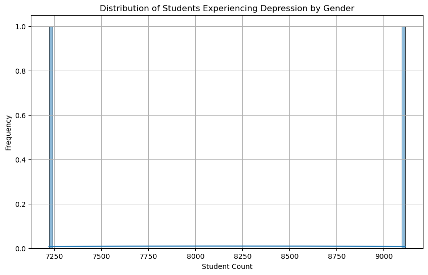

```python
plt.figure(figsize=(10, 6))  # Adjust figure size as needed
sns.histplot(Gender_depression_df['Student Count'], bins=100, kde=True, edgecolor='black')
plt.title('Distribution of Students Experiencing Depression by Gender')
plt.xlabel('Student Count')
plt.ylabel('Frequency')
plt.grid(True)
plt.show()
```

## Initial Patterns That Can Be Identified From The Data

### Box Plots for Numerical Variables and Outlier Analysis

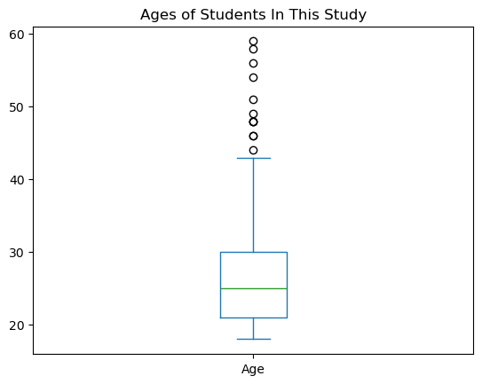

```python
df.plot(kind='box', y='Age', title= 'Ages of Students In This Study')
plt.show()
```

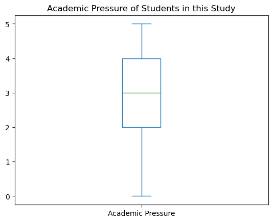

```python
df.plot(kind='box', y='Academic Pressure', title= 'Academic Pressure of Students in this Study')
plt.show()
```

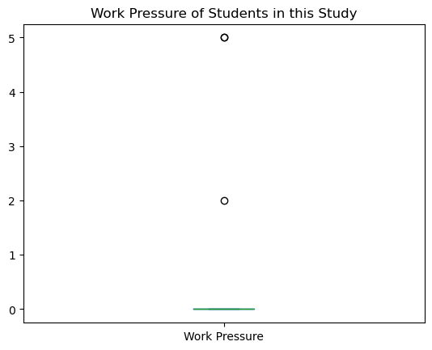

```python
df.plot(kind='box', y='Work Pressure', title= 'Work Pressure of Students in this Study')
plt.show()
```

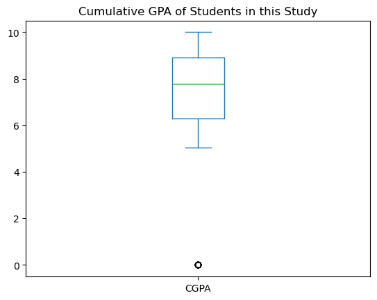

```python
df.plot(kind='box', y='CGPA', title= 'Cumulative GPA of Students in this Study')
plt.show()
```

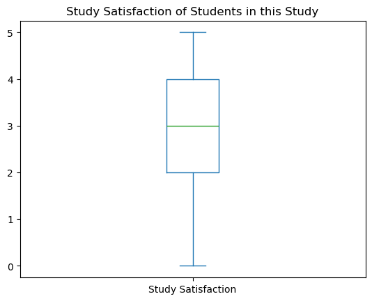

```python
df.plot(kind='box', y='Study Satisfaction', title= 'Study Satisfaction of Students in this Study')
plt.show()
```

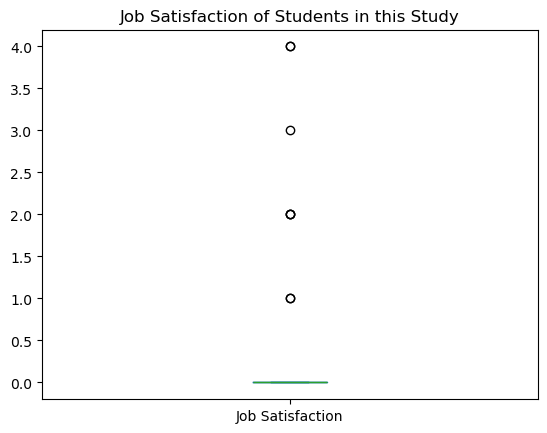

```python
df.plot(kind='box', y='Job Satisfaction', title= 'Job Satisfaction of Students in this Study')
plt.show()
```

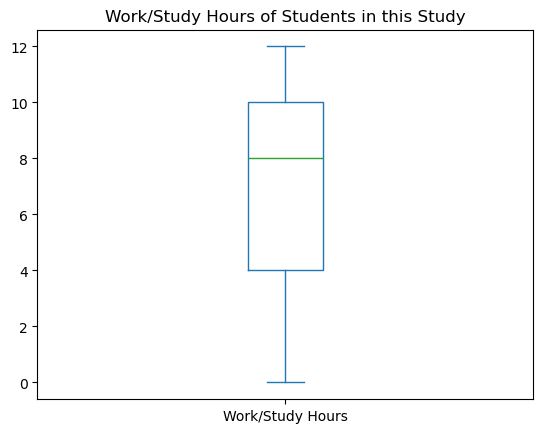

```python
df.plot(kind='box', y='Work/Study Hours', title= 'Work/Study Hours of Students in this Study')
plt.show()
```

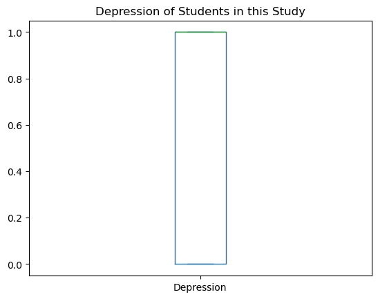

```python
df.plot(kind='box', y='Depression', title= 'Depression of Students in this Study')
plt.show()
```

##### There appears to be a few outliers with Job Satisfaction and Work Pressure above quartile 3, very few outliers below quartile 1 for CGPA, and a couple of outliers for Age above Quartile 3. What this would indicate is there are students in this study who feel they have great job Satisfaction or work Pressure, and a very small number of students who fall below the CGPA quartile 1 values, which is not much of a cause for concern and is reflective of a normal post secondary school environment. In the case of age what it does indiciate is while there are many students within Q1-Q3, there are a couple of mature students who are still pursuing higher education and this should not be a cause for concern either, as within any post secondary institution mature students are notably present. Overall, the outliers in the numerical dataset can be kept, given they are not a cause for concern and can be plausibly explained.

## What Machine Learning Model Will Be Used And Why

##### After conducting our analysis and visualizing the data we will be using a supervised machine learning model and take a logisitic regression approcach when creating our machine learning model.

##### We have chosen to use supervised machine learning because our dataset has a known target that we are trying to best predict, which is depression. As well throughout this project we will be aiming to predict/classify data on its ability to predict student's risk of depression, and we will be providing our model clear training examples when creating it.

##### We have chosen to build a logistic regression model because we are trying to predict a binary outcome in this case as noted within our dataset which is whether a student is or is not depressed. Logistic regression is also useful for providing probability based outcomes ranging from 0-1, which aligns with how depression is noted within our dataset. In this case logistic regression will also help us to best understand how our categorical and numerical independent variables influences if a student is or is not depressed.

## Data Quality Assessment

```python
df['Depression'].value_counts(normalize=True)
```

```
Depression
1    0.585499
0    0.414501
Name: proportion, dtype: float64
```

```python
df.duplicated().sum()
```

```
0
```

##### The outliers that have been discovered among our current numerical variables are not a cause for concern and should not be excluded, as noted earlier.

##### Finally, our current numerical variables do not appear to be normally distributed, however this is ok because a logistic regression model does not assume variables will be normally distributed.

# Part 2

## Value Counts for Categorical Features

```python
df.value_counts("Gender")
```

```
Gender
Male      15547
Female    12354
Name: count, dtype: int64
```

```python
df.value_counts("Age")
```

```
Age
24.0    2258
20.0    2237
28.0    2133
29.0    1950
33.0    1893
25.0    1784
21.0    1726
23.0    1645
18.0    1587
19.0    1560
34.0    1468
27.0    1462
31.0    1427
32.0    1262
22.0    1160
26.0    1155
30.0    1145
35.0      10
38.0       8
36.0       7
42.0       4
39.0       3
48.0       3
37.0       2
43.0       2
46.0       2
41.0       1
44.0       1
49.0       1
51.0       1
54.0       1
56.0       1
58.0       1
59.0       1
Name: count, dtype: int64
```

```python
df.value_counts("City")
```

```
City
Kalyan                  1570
Srinagar                1372
Hyderabad               1340
Vasai-Virar             1290
Lucknow                 1155
Thane                   1139
Ludhiana                1111
Agra                    1094
Surat                   1078
Kolkata                 1066
Jaipur                  1036
Patna                   1007
Visakhapatnam            969
Pune                     968
Ahmedabad                951
Bhopal                   934
Chennai                  885
Meerut                   825
Rajkot                   816
Delhi                    768
Bangalore                767
Ghaziabad                745
Mumbai                   699
Vadodara                 694
Varanasi                 685
Nagpur                   651
Indore                   643
Kanpur                   609
Nashik                   547
Faridabad                461
Bhavna                     2
Harsha                     2
Saanvi                     2
City                       2
Reyansh                    1
Rashi                      1
Vaanya                     1
'Less Delhi'               1
Nandini                    1
Nalyan                     1
Nalini                     1
Mira                       1
Mihir                      1
ME                         1
M.Tech                     1
'Less than 5 Kalyan'       1
Kibara                     1
Khaziabad                  1
Harsh                      1
Gaurav                     1
3.0                        1
M.Com                      1
Name: count, dtype: int64
```

```python
df.value_counts("Profession")
```

```
Profession
Student                     27870
Architect                       8
Teacher                         6
'Digital Marketer'              3
'Content Writer'                2
Chef                            2
Doctor                          2
Pharmacist                      2
'Civil Engineer'                1
'Educational Consultant'        1
'UX/UI Designer'                1
Entrepreneur                    1
Lawyer                          1
Manager                         1
Name: count, dtype: int64
```

```python
df.value_counts("Sleep Duration")
```

```
Sleep Duration
'Less than 5 hours'    8310
'7-8 hours'            7346
'5-6 hours'            6183
'More than 8 hours'    6044
Others                   18
Name: count, dtype: int64
```

```python
df.value_counts("Dietary Habits")
```

```
Dietary Habits
Unhealthy    10317
Moderate      9921
Healthy       7651
Others          12
Name: count, dtype: int64
```

```python
df.value_counts("Degree")
```

```
Degree
'Class 12'    6080
B.Ed          1867
B.Com         1506
B.Arch        1478
BCA           1433
MSc           1190
B.Tech        1152
MCA           1044
M.Tech        1022
BHM            925
BSc            888
M.Ed           821
B.Pharm        810
M.Com          734
MBBS           696
BBA            696
LLB            671
BE             613
BA             600
M.Pharm        582
MD             572
MBA            562
MA             544
PhD            522
LLM            482
MHM            191
ME             185
Others          35
Name: count, dtype: int64
```

```python
df.value_counts("Have you ever had suicidal thoughts ?")
```

```
Have you ever had suicidal thoughts ?
Yes    17656
No     10245
Name: count, dtype: int64
```

```python
df.value_counts("Financial Stress")
```

```
Financial Stress
5.0    6715
4.0    5775
3.0    5229
1.0    5121
2.0    5061
Name: count, dtype: int64
```

```python
df.value_counts("Family History of Mental Illness")
```

```
Family History of Mental Illness
No     14398
Yes    13503
Name: count, dtype: int64
```

## Data Preparation and Preprocessing

As noted in part 1 when reviewing the data types, the 'Financial Stress' variable should be a 'float' data type instead of an 'object'. Preprocessing to convert 'Financial Stress' from an 'object' to a 'float' was completed. Afterwhich, missing values were addressed. See 'Part 1' for details

### Converting Categorical Data

"Have you ever had suicidal thoughts ?" and "Family History of Mental Illness" were found to be binary feature with "Yes" & "No" values.  
This is similar to the target variable "Depression", which has "0" and "1" as outcomes. Encoding these values into numerical data allows for developed models to learn from the relationship between these features and the target variable. Both features will be binary encoded, similar to the target variable.

No = "0" Yes = "1"

```python
#Before Binary Encoding
print(df['Have you ever had suicidal thoughts ?'].unique())
print(df['Have you ever had suicidal thoughts ?'].dtype)

#Perform Binary Encoding
df['Have you ever had suicidal thoughts ?'] = df['Have you ever had suicidal thoughts ?'].replace({'No': 0, 'Yes': 1})

#After Binary Encoding
print(df['Have you ever had suicidal thoughts ?'].unique())
print(df['Have you ever had suicidal thoughts ?'].dtype)
```

```
['Yes' 'No']
object
[1 0]
int64
```

```python
#Before Binary Encoding
print(df['Family History of Mental Illness'].unique())
print(df['Family History of Mental Illness'].dtype)

#Perform Binary Encoding
df['Family History of Mental Illness'] = df['Family History of Mental Illness'].replace({'No': 0, 'Yes': 1})

#After Binary Encoding
print(df['Family History of Mental Illness'].unique())
print(df['Family History of Mental Illness'].dtype)
```

```
['No' 'Yes']
object
[0 1]
int64
```

```python
df.dtypes
```

```
id                                         int64
Gender                                    object
Age                                      float64
City                                      object
Profession                                object
Academic Pressure                        float64
Work Pressure                            float64
CGPA                                     float64
Study Satisfaction                       float64
Job Satisfaction                         float64
Sleep Duration                            object
Dietary Habits                            object
Degree                                    object
Have you ever had suicidal thoughts ?      int64
Work/Study Hours                         float64
Financial Stress                         float64
Family History of Mental Illness           int64
Depression                                 int64
dtype: object
```

```python
df.head(5)
```

|  | id | Gender | Age | City | Profession | Academic Pressure | Work Pressure | CGPA | Study Satisfaction | Job Satisfaction | Sleep Duration | Dietary Habits | Degree | Have you ever had suicidal thoughts ? | Work/Study Hours | Financial Stress | Family History of Mental Illness | Depression |
| --- | --- | --- | --- | --- | --- | --- | --- | --- | --- | --- | --- | --- | --- | --- | --- | --- | --- | --- |
| 0 | 2 | Male | 33.0 | Visakhapatnam | Student | 5.0 | 0.0 | 8.97 | 2.0 | 0.0 | '5-6 hours' | Healthy | B.Pharm | 1 | 3.0 | 1.0 | 0 | 1 |
| 1 | 8 | Female | 24.0 | Bangalore | Student | 2.0 | 0.0 | 5.90 | 5.0 | 0.0 | '5-6 hours' | Moderate | BSc | 0 | 3.0 | 2.0 | 1 | 0 |
| 2 | 26 | Male | 31.0 | Srinagar | Student | 3.0 | 0.0 | 7.03 | 5.0 | 0.0 | 'Less than 5 hours' | Healthy | BA | 0 | 9.0 | 1.0 | 1 | 0 |
| 3 | 30 | Female | 28.0 | Varanasi | Student | 3.0 | 0.0 | 5.59 | 2.0 | 0.0 | '7-8 hours' | Moderate | BCA | 1 | 4.0 | 5.0 | 1 | 1 |
| 4 | 32 | Female | 25.0 | Jaipur | Student | 4.0 | 0.0 | 8.13 | 3.0 | 0.0 | '5-6 hours' | Moderate | M.Tech | 1 | 1.0 | 1.0 | 0 | 0 |

#### Assuming Ordinality for Sleep Duration and Dietary Habits

"Sleep Duration" & "Dietary Habits" are categorical features that can be converted into numerical data. Both variables are assumed to be ordinal. For example, "Unhealthy" is viewed as lower than "Moderate" in the "Dietary Habits" feature. Likewise, "7-8 hours" is viewed as higher than "5-6 hours" in the "Sleep Duration" feature.

```python
df['Sleep Duration'] = (
    df['Sleep Duration']
    .astype(str)
    .str.replace("'", "", regex=False)
    .str.strip()
)
```

```python
#Assign numerical value to each category in Sleep Duration

sleepduration_order = {
    'Less than 5 hours': 0,
    '5-6 hours': 1,
    '7-8 hours': 2,
    'More than 8 hours': 3,
    'Others': np.nan
}
df['Sleep Duration'] = df['Sleep Duration'].replace(sleepduration_order)

print("Unique Sleep Duration values after mapping:")
print(df['Sleep Duration'].unique())
print("Sleep Duration dtype:", df['Sleep Duration'].dtype)
```

```
Unique Sleep Duration values after mapping:
```

```
[ 1.  0.  2.  3. nan]
Sleep Duration dtype: float64
```

```python
df['Sleep Duration'].value_counts()
```

```
Sleep Duration
0.0    8310
2.0    7346
1.0    6183
3.0    6044
Name: count, dtype: int64
```

```python
df['Sleep Duration'] = pd.to_numeric(df['Sleep Duration'], errors='coerce')
df['Sleep Duration'] = df['Sleep Duration'].fillna(df['Sleep Duration'].median())
print(df.isna().sum())
```

```
id                                       0
Gender                                   0
Age                                      0
City                                     0
Profession                               0
Academic Pressure                        0
Work Pressure                            0
CGPA                                     0
Study Satisfaction                       0
Job Satisfaction                         0
Sleep Duration                           0
Dietary Habits                           0
Degree                                   0
Have you ever had suicidal thoughts ?    0
Work/Study Hours                         0
Financial Stress                         0
Family History of Mental Illness         0
Depression                               0
dtype: int64
```

```python
df.head(5)
```

|  | id | Gender | Age | City | Profession | Academic Pressure | Work Pressure | CGPA | Study Satisfaction | Job Satisfaction | Sleep Duration | Dietary Habits | Degree | Have you ever had suicidal thoughts ? | Work/Study Hours | Financial Stress | Family History of Mental Illness | Depression |
| --- | --- | --- | --- | --- | --- | --- | --- | --- | --- | --- | --- | --- | --- | --- | --- | --- | --- | --- |
| 0 | 2 | Male | 33.0 | Visakhapatnam | Student | 5.0 | 0.0 | 8.97 | 2.0 | 0.0 | 1.0 | Healthy | B.Pharm | 1 | 3.0 | 1.0 | 0 | 1 |
| 1 | 8 | Female | 24.0 | Bangalore | Student | 2.0 | 0.0 | 5.90 | 5.0 | 0.0 | 1.0 | Moderate | BSc | 0 | 3.0 | 2.0 | 1 | 0 |
| 2 | 26 | Male | 31.0 | Srinagar | Student | 3.0 | 0.0 | 7.03 | 5.0 | 0.0 | 0.0 | Healthy | BA | 0 | 9.0 | 1.0 | 1 | 0 |
| 3 | 30 | Female | 28.0 | Varanasi | Student | 3.0 | 0.0 | 5.59 | 2.0 | 0.0 | 2.0 | Moderate | BCA | 1 | 4.0 | 5.0 | 1 | 1 |
| 4 | 32 | Female | 25.0 | Jaipur | Student | 4.0 | 0.0 | 8.13 | 3.0 | 0.0 | 1.0 | Moderate | M.Tech | 1 | 1.0 | 1.0 | 0 | 0 |

```python
#Assign numerical value to each category in Dietary Habits

dietaryhabits_order = {'Unhealthy': 0, 'Moderate': 1, 'Healthy': 2, 'Others': np.nan}

df['Dietary Habits'] = df['Dietary Habits'].replace(dietaryhabits_order)

print(df['Dietary Habits'].unique())
print(df['Dietary Habits'].dtype)
```

```
[ 2.  1.  0. nan]
float64
```

```python
print(df.isna().sum()) #Find missing values
```

```
id                                        0
Gender                                    0
Age                                       0
City                                      0
Profession                                0
Academic Pressure                         0
Work Pressure                             0
CGPA                                      0
Study Satisfaction                        0
Job Satisfaction                          0
Sleep Duration                            0
Dietary Habits                           12
Degree                                    0
Have you ever had suicidal thoughts ?     0
Work/Study Hours                          0
Financial Stress                          0
Family History of Mental Illness          0
Depression                                0
dtype: int64
```

```python
#Address missing values

df['Dietary Habits'] = df['Dietary Habits'].fillna(df['Dietary Habits'].median())
print(df.isna().sum())
```

```
id                                       0
Gender                                   0
Age                                      0
City                                     0
Profession                               0
Academic Pressure                        0
Work Pressure                            0
CGPA                                     0
Study Satisfaction                       0
Job Satisfaction                         0
Sleep Duration                           0
Dietary Habits                           0
Degree                                   0
Have you ever had suicidal thoughts ?    0
Work/Study Hours                         0
Financial Stress                         0
Family History of Mental Illness         0
Depression                               0
dtype: int64
```

```python
df.head(5)
```

|  | id | Gender | Age | City | Profession | Academic Pressure | Work Pressure | CGPA | Study Satisfaction | Job Satisfaction | Sleep Duration | Dietary Habits | Degree | Have you ever had suicidal thoughts ? | Work/Study Hours | Financial Stress | Family History of Mental Illness | Depression |
| --- | --- | --- | --- | --- | --- | --- | --- | --- | --- | --- | --- | --- | --- | --- | --- | --- | --- | --- |
| 0 | 2 | Male | 33.0 | Visakhapatnam | Student | 5.0 | 0.0 | 8.97 | 2.0 | 0.0 | 1.0 | 2.0 | B.Pharm | 1 | 3.0 | 1.0 | 0 | 1 |
| 1 | 8 | Female | 24.0 | Bangalore | Student | 2.0 | 0.0 | 5.90 | 5.0 | 0.0 | 1.0 | 1.0 | BSc | 0 | 3.0 | 2.0 | 1 | 0 |
| 2 | 26 | Male | 31.0 | Srinagar | Student | 3.0 | 0.0 | 7.03 | 5.0 | 0.0 | 0.0 | 2.0 | BA | 0 | 9.0 | 1.0 | 1 | 0 |
| 3 | 30 | Female | 28.0 | Varanasi | Student | 3.0 | 0.0 | 5.59 | 2.0 | 0.0 | 2.0 | 1.0 | BCA | 1 | 4.0 | 5.0 | 1 | 1 |
| 4 | 32 | Female | 25.0 | Jaipur | Student | 4.0 | 0.0 | 8.13 | 3.0 | 0.0 | 1.0 | 1.0 | M.Tech | 1 | 1.0 | 1.0 | 0 | 0 |

```python
df.describe()
```

|  | id | Age | Academic Pressure | Work Pressure | CGPA | Study Satisfaction | Job Satisfaction | Sleep Duration | Dietary Habits | Have you ever had suicidal thoughts ? | Work/Study Hours | Financial Stress | Family History of Mental Illness | Depression |
| --- | --- | --- | --- | --- | --- | --- | --- | --- | --- | --- | --- | --- | --- | --- |
| count | 27901.000000 | 27901.000000 | 27901.000000 | 27901.000000 | 27901.000000 | 27901.000000 | 27901.000000 | 27901.000000 | 27901.000000 | 27901.000000 | 27901.000000 | 27901.000000 | 27901.000000 | 27901.000000 |
| mean | 70442.149421 | 25.822300 | 3.141214 | 0.000430 | 7.656104 | 2.943837 | 0.000681 | 1.398695 | 0.904448 | 0.632809 | 7.156984 | 3.139852 | 0.483961 | 0.585499 |
| std | 40641.175216 | 4.905687 | 1.381465 | 0.043992 | 1.470707 | 1.361148 | 0.044394 | 1.126369 | 0.796796 | 0.482048 | 3.707642 | 1.437270 | 0.499752 | 0.492645 |
| min | 2.000000 | 18.000000 | 0.000000 | 0.000000 | 0.000000 | 0.000000 | 0.000000 | 0.000000 | 0.000000 | 0.000000 | 0.000000 | 1.000000 | 0.000000 | 0.000000 |
| 25% | 35039.000000 | 21.000000 | 2.000000 | 0.000000 | 6.290000 | 2.000000 | 0.000000 | 0.000000 | 0.000000 | 0.000000 | 4.000000 | 2.000000 | 0.000000 | 0.000000 |
| 50% | 70684.000000 | 25.000000 | 3.000000 | 0.000000 | 7.770000 | 3.000000 | 0.000000 | 1.000000 | 1.000000 | 1.000000 | 8.000000 | 3.000000 | 0.000000 | 1.000000 |
| 75% | 105818.000000 | 30.000000 | 4.000000 | 0.000000 | 8.920000 | 4.000000 | 0.000000 | 2.000000 | 2.000000 | 1.000000 | 10.000000 | 4.000000 | 1.000000 | 1.000000 |
| max | 140699.000000 | 59.000000 | 5.000000 | 5.000000 | 10.000000 | 5.000000 | 4.000000 | 3.000000 | 2.000000 | 1.000000 | 12.000000 | 5.000000 | 1.000000 | 1.000000 |

```python
df.dtypes
```

```
id                                         int64
Gender                                    object
Age                                      float64
City                                      object
Profession                                object
Academic Pressure                        float64
Work Pressure                            float64
CGPA                                     float64
Study Satisfaction                       float64
Job Satisfaction                         float64
Sleep Duration                           float64
Dietary Habits                           float64
Degree                                    object
Have you ever had suicidal thoughts ?      int64
Work/Study Hours                         float64
Financial Stress                         float64
Family History of Mental Illness           int64
Depression                                 int64
dtype: object
```

## Revised Correlation Analysis

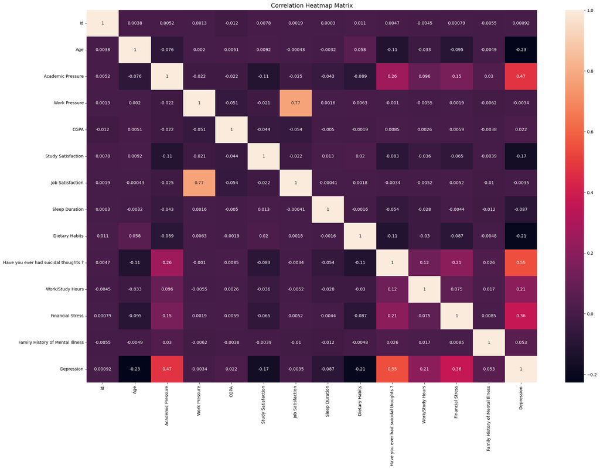

```python
plt.figure(figsize=(24, 16))
sns.heatmap(df.corr(numeric_only='true'), annot=True)
plt.title('Correlation Heatmap Matrix', fontsize=14)
plt.show()
```

Upon exploring the correlation matrix, it was determined numerical variables with a low correlation to the "Depression" target variable would be dropped. This included "Family History of Mental Illness", "Sleep Depression", "id", "Work Pressure", "CGPA", "Job Satisfaction", "Sleep Duration".

Also, it was determined "Age" would be dropped given depression can affect anyone at any stage in life. There are other underlying factors that may contribute to depression.

Lastly, "City", "Gender", "Degree", and "Profession" were not considered due to being categorical variables.

## Data Modeling

We will be using a supervised machine learning model and be taking a logistic regression approach when creating our machine learning model. We selected this approach because our dataset has a known target variable (depression) that we are trying to best predict. As well throughout this project we will be providing our model clear training examples when creating it.

A logistic regression model was chosen because we are trying to predict a binary outcome which in this case is whether a student is or is not depressed. Logistic regression is also useful for providing probability outcomes ranging from 0-1, which aligns with the binary nature of depression in this dataset.

In order to test the accuracy of the model, we will create a Random Forest classifier model for comparison. This classfication model can also be used to predict a binary outcome with a known target variable.

### Separating Target variable and features

```python
features = [
    'Academic Pressure',
    'Financial Stress',
    'Study Satisfaction',
    'Work/Study Hours',
    'Dietary Habits',
    'Have you ever had suicidal thoughts ?'
]
target = 'Depression'
```

```python
df[target] = df[target].replace({
    'Yes': 1,
    'No': 0
})
```

### Separating Target variable and features

```python
X = df[features]
y = df[target]
```

```python
df[features] = df[features].replace('?', np.nan)
df[target] = df[target].replace('?', np.nan)
```

```python
numeric_cols = ['Academic Pressure', 'Financial Stress', 'Study Satisfaction', 'Work/Study Hours']
for col in numeric_cols:
    df[col] = pd.to_numeric(df[col], errors='coerce')
```

## Model #1 - Logistic Regression Model

```python
X_train_lr, X_test_lr, y_train_lr, y_test_lr = train_test_split(X, y, test_size=0.3) #70% train, 30% test
```

```python
scaler = StandardScaler()
X_train_lr = scaler.fit_transform(X_train_lr)
X_test_lr = scaler.transform(X_test_lr)
```

```python
model = LogisticRegression()
model.fit(X_train_lr, y_train_lr)
y_pred_lr = model.predict(X_test_lr)
print("Accuracy Score:", accuracy_score(y_test_lr, y_pred_lr))
```

```
Accuracy Score: 0.8347867638274997
```

```python
model.intercept_
```

```
array([0.55975914])
```

```python
model.coef_
```

```
array([[ 1.14113256,  0.81428695, -0.32065858,  0.42910805, -0.43600891,
         1.20281202]])
```

```python
coefficients_lr = model.coef_[0]
feature_importance_lr = pd.DataFrame({'Feature': X.columns, 'Importance': coefficients_lr})
print(feature_importance_lr)
```

```
                                 Feature  Importance
0                      Academic Pressure    1.141133
1                       Financial Stress    0.814287
2                     Study Satisfaction   -0.320659
3                       Work/Study Hours    0.429108
4                         Dietary Habits   -0.436009
5  Have you ever had suicidal thoughts ?    1.202812
```

```python
df.columns
```

```
Index(['id', 'Gender', 'Age', 'City', 'Profession', 'Academic Pressure',
       'Work Pressure', 'CGPA', 'Study Satisfaction', 'Job Satisfaction',
       'Sleep Duration', 'Dietary Habits', 'Degree',
       'Have you ever had suicidal thoughts ?', 'Work/Study Hours',
       'Financial Stress', 'Family History of Mental Illness', 'Depression'],
      dtype='object')
```

```python
# First column (index = 0) --> Probability of Depression = 0
# Second column (index = 1) ---> Probability of Depression = 1
model.predict_proba(X_train_lr)
```

```
array([[0.98561338, 0.01438662],
       [0.08394689, 0.91605311],
       [0.12615352, 0.87384648],
       ...,
       [0.0610421 , 0.9389579 ],
       [0.98720505, 0.01279495],
       [0.97560404, 0.02439596]])
```

```python
comparison_df = pd.DataFrame({'Actual': y_test_lr, 'Predicted': y_pred_lr})
print(comparison_df.head(20))
```

```
       Actual  Predicted
20649       0          0
26949       1          1
769         1          0
25283       1          1
20025       0          0
24276       1          1
15487       0          0
10993       1          1
17211       0          0
6399        1          1
20046       1          1
4167        1          1
20173       0          0
21413       1          0
23143       1          0
9496        1          1
13863       0          0
25515       1          1
27056       1          0
8695        0          0
```

```python
print("\nClassification Report:\n", classification_report(y_test_lr, y_pred_lr, target_names=['Not Depressed', 'Depressed']))
```

```
Classification Report:
                precision    recall  f1-score   support

Not Depressed       0.81      0.78      0.79      3446
    Depressed       0.85      0.87      0.86      4925

     accuracy                           0.83      8371
    macro avg       0.83      0.83      0.83      8371
 weighted avg       0.83      0.83      0.83      8371
```

```python
confusion_matrix(y_test_lr, y_pred_lr)
```

```
array([[2679,  767],
       [ 616, 4309]], dtype=int64)
```

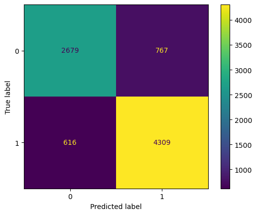

```python
cm_lr = confusion_matrix(y_test_lr, y_pred_lr)
disp = ConfusionMatrixDisplay(confusion_matrix=cm_lr)
disp.plot()
plt.show()
```

Due to being a binary outcome, scatterplot is not effectively showing probability of belonging to one of the outcomes as the independent variable changes. As such, using histogram instead.

```python
y_prob_lr = model.predict_proba(X_test_lr)[:, 1]  # Get probabilities for ROC AUC
#selects columns with index 1, Depression = 1
```

```python
print (y_prob_lr)
```

```
[0.03006586 0.97030312 0.13581647 ... 0.8582561  0.92000154 0.03692998]
```

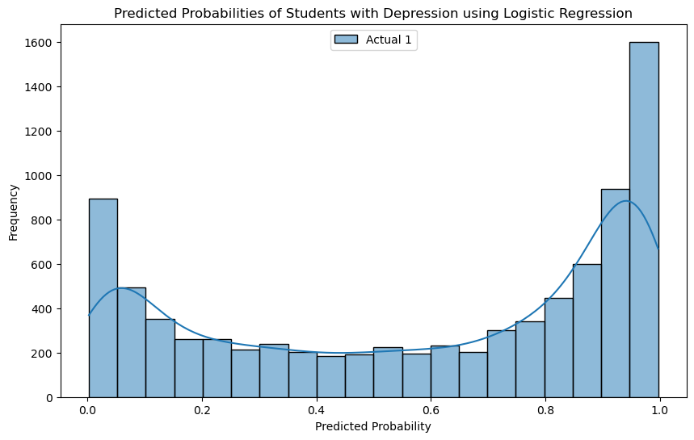

```python
# Create histograms of predicted probabilities
plt.figure(figsize=(10, 6))
#sns.histplot(y_prob_lr[y_test_lr == 0], bins=20, alpha=0.5, kde=True, label='Actual 0')
#sns.histplot(y_prob_lr[y_test_lr == 1], bins=20, alpha=0.5, kde=True, label='Actual 1')
sns.histplot(y_prob_lr, bins=20, alpha=0.5, kde=True, label='Actual 1')

plt.title('Predicted Probabilities of Students with Depression using Logistic Regression')
plt.xlabel('Predicted Probability')
plt.ylabel('Frequency')
plt.legend(loc='upper center')
plt.show()
```

### K-folds Cross Validation for Logistic Regression Model

```python
kf_lr = KFold (n_splits = 10, shuffle = True, random_state = 1)
model_lr = LogisticRegression()
cv_score_lr = cross_val_score(model_lr, X, y, cv = kf_lr)
```

```python
#list the scores from the 10 folds
cv_score_lr
```

```
array([0.84593336, 0.8437276 , 0.83476703, 0.83010753, 0.82401434,
       0.84695341, 0.83405018, 0.83584229, 0.83512545, 0.83870968])
```

```python
#take the average score, and compare this result to the accuracy score
#produced earlier without kfolds
np.mean(cv_score_lr)
```

```
0.8369230848259059
```

```python
#get 95% confidence intervals of the score
np.quantile(cv_score_lr, [0.025, 0.975])
```

```
array([0.8253853 , 0.84672389])
```

#### Conclusion

The logistic Regression model was found to be ~83.69% accurate in its predictions.

## Model #2 - Random Forest Classifier Model

```python
#Splitting Data into Training and Testing sets

X_train_rf, X_test_rf, y_train_rf, y_test_rf = train_test_split(X, y, test_size=0.3, random_state=42)  #70% train, 30% test
```

```python
#Normalize Data

scaler = StandardScaler()
X_train_rf = scaler.fit_transform(X_train_rf)
X_test_rf = scaler.transform(X_test_rf)
```

```python
#Random Forest Model

rf = RandomForestClassifier(n_estimators=100, random_state=42)
rf.fit(X_train_rf, y_train_rf)
pred_rf = rf.predict(X_test_rf)
accuracy_rf = accuracy_score(y_test_rf, pred_rf)
```

```python
print(accuracy_rf)
```

```
0.7971568510333293
```

```python
#Find feature importances in random forest model
rf_feature_importances = rf.feature_importances_
rf_feature_names = X.columns

print("Feature Importances:")
for name, importance in zip(rf_feature_names, rf_feature_importances):
    print(f"{name}: {importance:.4f}")
```

```
Feature Importances:
Academic Pressure: 0.2248
Financial Stress: 0.1360
Study Satisfaction: 0.0939
Work/Study Hours: 0.1945
Dietary Habits: 0.0554
Have you ever had suicidal thoughts ?: 0.2954
```

### In Sample Performance

```python
# First column (index = 0) --> Probability of Depression = 0
# Second column (index = 1) ---> Probability of Depression = 1

rf.predict_proba(X_train_rf)
```

```
array([[0.94      , 0.06      ],
       [0.        , 1.        ],
       [0.        , 1.        ],
       ...,
       [0.13767888, 0.86232112],
       [0.91587554, 0.08412446],
       [0.98833333, 0.01166667]])
```

```python
roc_auc_score(y_train_rf, rf.predict_proba(X_train_rf)[:,1] )
```

```
0.9728105685129619
```

### Out of Sample Performance

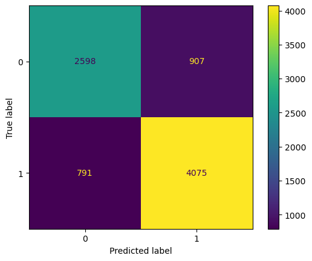

```python
cm_rf = confusion_matrix(y_test_rf, pred_rf)
disp_rf = ConfusionMatrixDisplay(confusion_matrix=cm_rf)
disp_rf.plot()
plt.show()
```

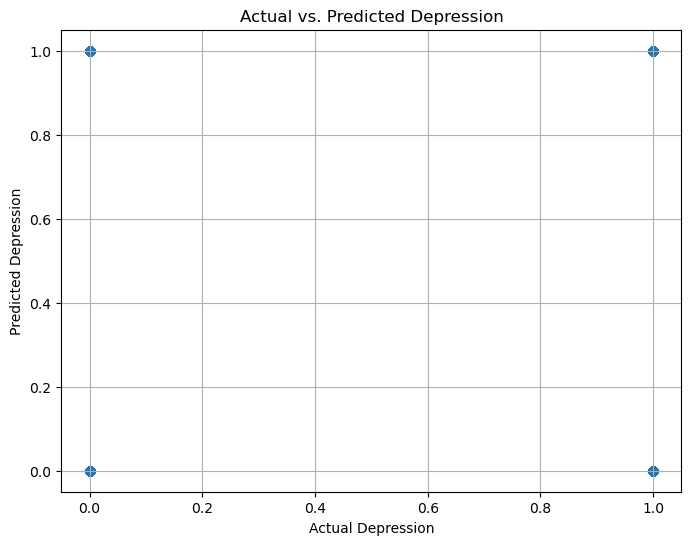

```python
#Due to being a binary outcome, scatterplot is not effectively showing probability of belonging to one of the outcomes as the
#independent variable changes.  As such, using histogram and boxplot instead

plt.figure(figsize=(8, 6))
plt.scatter(y_test_rf, pred_rf, alpha=0.5)
plt.title('Actual vs. Predicted Depression')
plt.xlabel('Actual Depression')
plt.ylabel('Predicted Depression')
plt.grid(True)
plt.show()
```

```python
y_prob_rf = rf.predict_proba(X_test_lr)[:, 1]  # Get probabilities for ROC AUC
#selects columns with index 1, Depression = 1
```

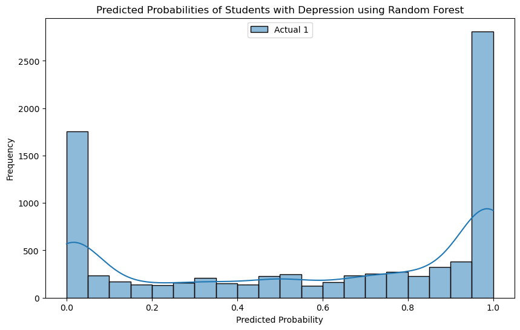

```python
# Create histograms of predicted probabilities
plt.figure(figsize=(10, 6))
#sns.histplot(y_prob_rf[y_test_rf == 0], bins=20, alpha=0.5, kde=True, label='Actual 0')
#sns.histplot(y_prob_rf[y_test_rf == 1], bins=20, alpha=0.5, kde=True, label='Actual 1')
sns.histplot(y_prob_rf, bins=20, alpha=0.5, kde=True, label='Actual 1')

plt.title('Predicted Probabilities of Students with Depression using Random Forest')
plt.xlabel('Predicted Probability')
plt.ylabel('Frequency')
plt.legend(loc='upper center')
plt.show()
```

```python
tn, fp, fn, tp = cm_rf.ravel() #true negative, false positive, false negative, true positive
tn, fp, fn, tp
```

```
(2598, 907, 791, 4075)
```

```python
#accuracy
(tp+tn)/(tn+fp+fn+tp)
```

```
0.7971568510333293
```

```python
#Precision
tp/(tp+fp)
```

```
0.8179446005620233
```

```python
#Recall
tp/(tp+fn)
```

```
0.8374434854089602
```

```python
#Specificity
tn/(tn+fp)
```

```
0.7412268188302426
```

```python
#F1 score
precision = tp/(tp+fp)
recall = tp/(tp+fn)

F1score = 2 *(precision*recall)/(precision+recall)
F1score
```

```
0.827579203899269
```

```python
#Generate a full classification report
print(classification_report(y_test_rf, pred_rf))
```

```
              precision    recall  f1-score   support

           0       0.77      0.74      0.75      3505
           1       0.82      0.84      0.83      4866

    accuracy                           0.80      8371
   macro avg       0.79      0.79      0.79      8371
weighted avg       0.80      0.80      0.80      8371
```

### K-folds Cross Validation for Random Forest Classifier

```python
kf_rf = KFold (n_splits = 10, shuffle = True, random_state = 1)
rf = RandomForestClassifier()
cv_score_rf = cross_val_score(rf, X, y, cv = kf_rf)
```

```python
#list the scores from the 10 folds
cv_score_rf
```

```
array([0.8169115 , 0.81218638, 0.79283154, 0.80716846, 0.79354839,
       0.81863799, 0.8       , 0.79820789, 0.80967742, 0.80573477])
```

```python
#take the average score, and compare this result to the accuracy score
#produced earlier without kfolds
np.mean(cv_score_rf)
```

```
0.805490433279525
```

```python
#get 95% confidence intervals of the score
np.quantile(cv_score_rf, [0.025, 0.975])
```

```
array([0.79299283, 0.81824953])
```

### Conclusion

Overall, the random forest learning model has proven to be approximately 80.55% accurate in its predictions

## Final Conclusion

Upon reviewing the accuracy of both models, it appear the logistic regression is more accurate than the random forest classifier. It was would the logistic model had an accuracy of 83.69% while the random forest model had an accuracy of 80.55%.

As a result, the logistic regression model will be our chosen learning model.